# HW1

Mehmet Ali Erkan

5/29/2022

# Question 1

Reading, Splitting and General Arrangments on the Dataset

```r
library(readxl)
titanic <- read_excel("titanic.xlsx")
#omit NA value
titanic <- na.omit(titanic)


#Convert some variable to the factor.
titanic$Sex <- as.factor(titanic$Sex)
titanic$Survived <- as.factor(titanic$Survived)
titanic$Embarked <- as.factor(titanic$Embarked)
titanic$Pclass <- as.factor(titanic$Pclass)

#split the data set
set.seed(364)
sp <- sample(1:nrow(titanic), nrow(titanic)*0.8)
train <- titanic[sp,]
test <- titanic[-sp,]
head(titanic)
```

| Pclass | Sex | Age | SibSp | Parch | Fare | Embarked | Survived |
| --- | --- | --- | --- | --- | --- | --- | --- |
| 3 | male | 22 | 1 | 0 | 7.2500 | S | 0 |
| 1 | female | 38 | 1 | 0 | 71.2833 | C | 1 |
| 3 | female | 26 | 0 | 0 | 7.9250 | S | 1 |
| 1 | female | 35 | 1 | 0 | 53.1000 | S | 1 |
| 3 | male | 35 | 0 | 0 | 8.0500 | S | 0 |
| 1 | male | 54 | 0 | 0 | 51.8625 | S | 0 |

### Part A

```r
model <- glm(Survived ~ . , data = train , family = "binomial")
summary(model)
```

```
##
## Call:
## glm(formula = Survived ~ ., family = "binomial", data = train)
##
## Deviance Residuals:
##     Min       1Q   Median       3Q      Max
## -2.4282  -0.6212  -0.3849   0.6025   2.4827
##
## Coefficients:
##              Estimate Std. Error z value Pr(>|z|)
## (Intercept)  4.710340   0.624114   7.547 4.45e-14 ***
## Pclass2     -1.233562   0.389083  -3.170  0.00152 **
## Pclass3     -2.467235   0.405907  -6.078 1.21e-09 ***
## Sexmale     -2.683840   0.251765 -10.660  < 2e-16 ***
## Age         -0.051318   0.009463  -5.423 5.85e-08 ***
## SibSp       -0.310031   0.140595  -2.205  0.02744 *
## Parch       -0.088269   0.136048  -0.649  0.51646
## Fare         0.001662   0.003299   0.504  0.61455
## EmbarkedQ   -0.648803   0.663307  -0.978  0.32801
## EmbarkedS   -0.298319   0.309379  -0.964  0.33492
## ---
## Signif. codes:  0 '***' 0.001 '**' 0.01 '*' 0.05 '.' 0.1 ' ' 1
##
## (Dispersion parameter for binomial family taken to be 1)
##
##     Null deviance: 770.78  on 568  degrees of freedom
## Residual deviance: 499.45  on 559  degrees of freedom
## AIC: 519.45
##
## Number of Fisher Scoring iterations: 5
```

The Model is:
$$y = 4.71 - 1.23*x1 -2.46*x2 -2.68*x3 -0.05*x4 -0.31*x5 - 0.08*x6 +
0.001*x7 - 0.64*x8 -0.29*x9$$

### Part B

We write the model equation in part A, now let’s interpret them linear linear and exponentiated terms.

First take the coefficents. And then interpret the exponentially.

For the SECOND PASSENGER CLASS

1.23 is the decrease in the log-odd value that when second passenger class when the other variables held constant, the otherwise $e^{-1.23}$ is the odds ratio resulting from the second passenger class when the other variables held constant.

```r
(exp(-1.23)-1)*100
```

```
## [1] -70.77074
```

The odds of Survived decreases by 70.77 percent with a changing second passenger class when the other variables held constant.

For the THIRD PASSENGER CLASS

2.46 is the decrease in the log-odd value that when third passenger class when the other variables held constant, the otherwise $e^{-2.46}$ is the odds ratio resulting from the third passenger class when the other variables held constant.

```r
(exp(-2.46)-1)*100
```

```
## [1] -91.4565
```

The odds of Survived decreases by 91.45 percent with a changing third passenger class when the other variables held constant.

For the MALE

2.68 is the decrease in the log-odd value that when male class when the other variables held constant, the otherwise $e^{-2.68}$ is the odds ratio resulting from the male class when the other variables held constant.

```r
(exp(-2.68)-1)*100
```

```
## [1] -93.14368
```

The odds of Survived decreases by 93.14 percent with a male class when the other variables held constant.

For the AGE

0.05 is the decrease in the log-odd value that when age class when the other variables held constant, the otherwise $e^{-0.05}$ is the odds ratio resulting from the age class when the other variables held constant.

```r
(exp(-0.05)-1)*100
```

```
## [1] -4.877058
```

The odds of Survived decreases by 4.87 percent with a age class when the other variables held constant.

For the NUMBER OF SIBLINGS

0.31 is the decrease in the log-odd value that when number of sibling class when the other variables held constant, the otherwise $e^{-0.31}$ is the odds ratio resulting from the number of age class when the other variables held constant.

```r
(exp(-0.31)-1)*100
```

```
## [1] -26.6553
```

The odds of Survived decreases by 26.65 percent with a number of sibling class when the other variables held constant.

For the NUMBER OF PARENTS

0.088 is the decrease in the log-odd value that when number of parents class when the other variables held constant, the otherwise $e^{-0.088}$ is the odds ratio resulting from the number of parents class when the other variables held constant.

```r
(exp(-0.088)-1)*100
```

```
## [1] -8.423912
```

The odds of Survived decreases by 8.42 percent with a number of parents class when the other variables held constant.

For the FARE (British pound) VARIABLE

0.001 is the increase in the log-odd value that when fare (British pound) class when the other variables held constant, the otherwise $e^{0.001}$ is the odds ratio resulting from the fare (British pound) class when the other variables held constant.

```r
(exp(0.001)-1)*100
```

```
## [1] 0.10005
```

The odds of Survived increased by 0.1 percent with a fare (British pound) class when the other variables held constant.

For the QUEENSTOWN EMBARKED VARIABLE

0.64 is the decrease in the log-odd value that when queenstown embarked class when the other variables held constant, the otherwise $e^{-0.64}$ is the odds ratio resulting from the queenstown embarked class when the other variables held constant.

```r
(exp(-0.64)-1)*100
```

```
## [1] -47.27076
```

The odds of Survived decreases by 47 percent with a queenstown embarked class when the other variables held constant.

For the SOUTHAMPTON EMBARKED VARIABLE

0.29 is the decrease in the log-odd value that when southampton embarked class when the other variables held constant, the otherwise $e^{-0.29}$ is the odds ratio resulting from the southampton embarked class when the other variables held constant.

```r
(exp(-0.29)-1)*100
```

```
## [1] -25.17364
```

The odds of Survived decreases by 25 percent with a southampton embarked class when the other variables held constant.

### Part C

Estimated probability of a female passenger in class 3 at age 35 with no siblings or spouse, no parents or children who also paid 75 pounds and embarked the ship at Cherbourg survived is 0.6399.

These are the calculation:

```r
exp(4.71 - 1.23*0 - 2.46*1 - 2.68*0 - 0.05*35 - 0.31*0 - 0.08*0 + 0.001*75 - 0.64*0 - 0.29*0) / (1+exp(4.71 - 1.23*0 - 2.46*1 - 2.68*0 - 0.05*35 - 0.31*0 - 0.08*0 + 0.001*75 - 0.64*0 - 0.29*0))
```

```
## [1] 0.6399161
```

The estimated probability that a female passenger in class 3 at age 35 with no siblings or spouse, no parents or children who also paid 75 pounds and embarked the ship at Cherbourg survived is 0.6399.

### Part D

The Hypothesis are:
$$H_0:\beta_k=0 \ and \ H_a:\beta_k \neq 0$$

We use the formula of :
$$z = {\beta_x / se({\beta_x})}$$
which x is a parameter for 1 to 9.

The decision rule is:

$$|z^{*}| \leq z(1-\alpha/2),\ conclude \ H_0$$
Otherwise
$$|z^{*}| > z(1-\alpha/2),\ conclude \ H_a$$
I put the values from the model(summary) in part A.

```r
x1_test <- -1.2335 / 0.3890
x2_test <- -2.4672 / 0.4059
x3_test <- -2.6838 / 0.2517
x4_test <- -0.0513 / 0.0094
x5_test <- -0.3100 / 0.1405
x6_test <- -0.0882 / 0.1360
x7_test <- 0.0016 / 0.0032
x8_test <- -0.6488 / 0.6633
x9_test <- -0.2983 / 0.3093
print(c(x1_test,x2_test,x3_test,x4_test,x5_test,x6_test,x7_test,x8_test,x9_test))
```

```
## [1]  -3.1709512  -6.0783444 -10.6626937  -5.4574468  -2.2064057  -0.6485294
## [7]   0.5000000  -0.9781396  -0.9644358
```

Critical Value z = 2.575 for level at 0.01

Thus, We can not reject H0 for the x5,x6,x7,x8 and x9. x1,x2,x3 and x4 have a significant relationship between Survived variable.

### Part E

The whole procedure is:

$H_{0}$: The coefficients you are interested in are zero. (Reduced model) $H_{a}$: Not all of the coefficients in $H_0$ are zero. (Full model)

Test statistic is:

$$LR=2ln(\frac{L(FM)}{L(RM)}) = 2(lnL(FM) - lnL(RM))$$

```r
#Built the model
model1 <- glm(Survived ~ . , data = train , family = "binomial")
reduced.model <- glm(Survived ~ 1, data = train, family="binomial")

#Test statistics
2*(logLik(model1) - logLik(reduced.model))
```

```
## 'log Lik.' 271.3238 (df=10)
```

```r
#CriticL value
qchisq(0.1, 10, lower.tail = F)
```

```
## [1] 15.98718
```

Now, we can make a decision based on the decision rule.

LR=271.3238 > $\chi^{2}(0.1,10)$. Thus, we can conclude that $H_{1}$, meaning we reject that the reduced model is appropriate. Model is significant.

### Part F

The approximate $1-\alpha$ confidence limits for $\beta_k$
$$\hat \beta_k \pm z(1-\alpha/2)se(\hat \beta_k)$$
Thus our confidence intervals for the parameters:

```r
b1_conf <- print(paste(-1.2335 - 0.3890*1.959964, -1.2335 + 0.3890*1.959964))
```

```
## [1] "-1.995925996 -0.471074004"
```

```r
b2_conf <- print(paste(-2.4672 - 0.4059*1.959964, -2.4672 + 0.4059*1.959964))
```

```
## [1] "-3.2627493876 -1.6716506124"
```

```r
b3_conf <- print(paste(-2.6838 - 0.2517*1.959964, -2.6838 + 0.25117*1.959964))
```

```
## [1] "-3.1771229388 -2.19151584212"
```

```r
b4_conf <- print(paste(-0.0513 - 0.0094*1.959964, -0.0513 + 0.0094*1.959964))
```

```
## [1] "-0.0697236616 -0.0328763384"
```

```r
b5_conf <- print(paste(-0.3100 - 0.1405*1.959964, -0.3100 + 0.1405*1.959964))
```

```
## [1] "-0.585374942 -0.034625058"
```

```r
b6_conf <- print(paste(-0.0882 - 0.1360*1.959964, -0.0882 + 0.1360*1.959964))
```

```
## [1] "-0.354755104 0.178355104"
```

```r
b7_conf <- print(paste( 0.0016 - 0.0032*1.959964, 0.0016 +0.0032*1.959964))
```

```
## [1] "-0.0046718848 0.0078718848"
```

```r
b8_conf <- print(paste( -0.6488 - 0.6633*1.959964, -0.6488 + 0.6633*1.959964))
```

```
## [1] "-1.9488441212 0.6512441212"
```

```r
b9_conf <- print(paste( -0.2983 - 0.3093*1.959964, -0.2983 + 0.3093*1.959964))
```

```
## [1] "-0.9045168652 0.3079168652"
```

We expect the confidince interval for $\hat \beta_1$ between -1.9959, -0.4710. We expect the confidince interval for $\hat \beta_2$ between -3.2627, -1.6716. We expect the confidince interval for $\hat \beta_3$ between -3.177, -2.1915. We expect the confidince interval for $\hat \beta_4$ between -0.0697, -0.0328. We expect the confidince interval for $\hat \beta_5$ between -0.5853, -0.0346. We expect the confidince interval for $\hat \beta_6$ between -0.3547, 0.1783. We expect the confidince interval for $\hat \beta_7$ between -0.0046, 0.0078. We expect the confidince interval for $\hat \beta_8$ between -1.9488, 0.6512. We expect the confidince interval for $\hat \beta_9$ between -0.9045, 0.3079.

### Part G

The corresponding confidence limits for the odds ratio $exp(\beta_k)$ are :
$$exp(\hat \beta_k \pm z(1-\alpha/2)se(\hat \beta_k))$$

```r
b1_conf_odds <- print(paste(exp(-1.2335 - 0.3890*1.959964), exp(-1.2335 + 0.3890*1.959964)))
```

```
## [1] "0.135887764362868 0.624331373682787"
```

```r
b2_conf_odds <- print(paste(exp(-2.4672 - 0.4059*1.959964), exp(-2.4672 +  0.4059*1.959964)))
```

```
## [1] "0.0382829983906665 0.187936598998472"
```

```r
b3_conf_odds <- print(paste(exp(-2.6838 - 0.2517*1.959964), exp(-2.6838 + 0.2517*1.959964)))
```

```
## [1] "0.041705471873415 0.111863370212329"
```

```r
b4_conf_odds <- print(paste(exp(-0.0513 - 0.0094*1.959964), exp(-0.0513 + 0.0094*1.959964)))
```

```
## [1] "0.932651511725744 0.96765821435357"
```

```r
b5_conf_odds <- print(paste(exp(-0.3100 - 0.1405*1.959964), exp(-0.3100 + 0.1405*1.959964)))
```

```
## [1] "0.55689701858063 0.965967530165163"
```

```r
b6_conf_odds <- print(paste(exp(-0.0882 - 0.1360*1.959964), exp(-0.0882 + 0.1360*1.959964)))
```

```
## [1] "0.701345178807943 1.19524968382764"
```

```r
b7_conf_odds <- print(paste(exp(0.0016 - 0.0032*1.959964),exp(0.0016 +0.0032*1.959964)))
```

```
## [1] "0.995339011478469 1.00790294954435"
```

```r
b8_conf_odds <- print(paste(exp(-0.6488 - 0.6633*1.959964), exp(-0.6488 + 0.6633*1.959964)))
```

```
## [1] "0.142438618249329 1.91792547705674"
```

```r
b9_conf_odds <- print(paste(exp(-0.2983 - 0.3093*1.959964),exp(-0.2983 + 0.3093*1.959964)))
```

```
## [1] "0.404737380587303 1.36058787203462"
```

We expect the odds ratio to between 0.1358 and 0.6243 with 95% condfidence for $exp(\beta_1)$. We expect the odds ratio to between 0.038 and 0.18 with 95% condfidence for $exp(\beta_2)$. We expect the odds ratio to between 0.0417 and 0.1118 with 95% condfidence for $exp(\beta_3)$. We expect the odds ratio to between 0.9326 and 0.9676 with 95% condfidence for $exp(\beta_4)$. We expect the odds ratio to between 0.5568 and 0.9659 with 95% condfidence for $exp(\beta_5)$. We expect the odds ratio to between 0.7013 and 1.1952 with 95% condfidence for $exp(\beta_6)$. We expect the odds ratio to between 0.9953 and 1.007 with 95% condfidence for $exp(\beta_7)$. We expect the odds ratio to between 0.1424 and 1.9179 with 95% condfidence for $exp(\beta_8)$. We expect the odds ratio to between 0.4047 and 1.3605 with 95% condfidence for $exp(\beta_9)$.

### Part H

```r
library(ResourceSelection)
hoslem.test(model1$y, fitted(model1))
```

```
##
##  Hosmer and Lemeshow goodness of fit (GOF) test
##
## data:  model1$y, fitted(model1)
## X-squared = 11.572, df = 8, p-value = 0.1713
```

Since p-value is greater than alpha value, we cannot reject H0. Thus, we conclude that the model is good fit.

### Part I

```r
#Scoring to the test data

probability <- predict(model,test, type = "response")

#Matrix for confussion and accuracy

prediction <- rep(0,nrow(test))
prediction[probability > 0.5] = 1
t_value <- table(prediction,test$Survived)
library(caret)

TP <- 40
FP <- 19
FN <- 14
TN <- 70
number_of_row <- nrow(test)

accuracy <- (TP+TN)/number_of_row
classification_error <- (FP+FN)/number_of_row
specificity <- TN/(TN+FP)
sensitivity <-  TP/(TP+FN)
negative_prediction_value <- TN/(TN+FN)
positive_prediction_value <- TP/(TP+FP)
prevalence <- (TP+FN)/number_of_row
detection <- TP/number_of_row
detection_prevalence <- (TP+FP)/number_of_row
balanced_accuracy <- (sensitivity+specificity)/2
no_info_rate <- (TP+FP)/number_of_row

data.frame(accuracy,classification_error,specificity,sensitivity,positive_prediction_value,
           negative_prediction_value,prevalence,detection,detection_prevalence,balanced_accuracy, no_info_rate)
```

```
##    accuracy classification_error specificity sensitivity
## 1 0.7692308            0.2307692   0.7865169   0.7407407
##   positive_prediction_value negative_prediction_value prevalence detection
## 1                 0.6779661                 0.8333333  0.3776224 0.2797203
##   detection_prevalence balanced_accuracy no_info_rate
## 1            0.4125874         0.7636288    0.4125874
```

```r
confusionMatrix(t_value,positive = "1")
```

```
## Confusion Matrix and Statistics
##
##
## prediction  0  1
##          0 70 14
##          1 19 40
##
##                Accuracy : 0.7692
##                  95% CI : (0.6915, 0.8355)
##     No Information Rate : 0.6224
##     P-Value [Acc > NIR] : 0.0001301
##
##                   Kappa : 0.5178
##
##  Mcnemar's Test P-Value : 0.4862343
##
##             Sensitivity : 0.7407
##             Specificity : 0.7865
##          Pos Pred Value : 0.6780
##          Neg Pred Value : 0.8333
##              Prevalence : 0.3776
##          Detection Rate : 0.2797
##    Detection Prevalence : 0.4126
##       Balanced Accuracy : 0.7636
##
##        'Positive' Class : 1
##
```

### Part J

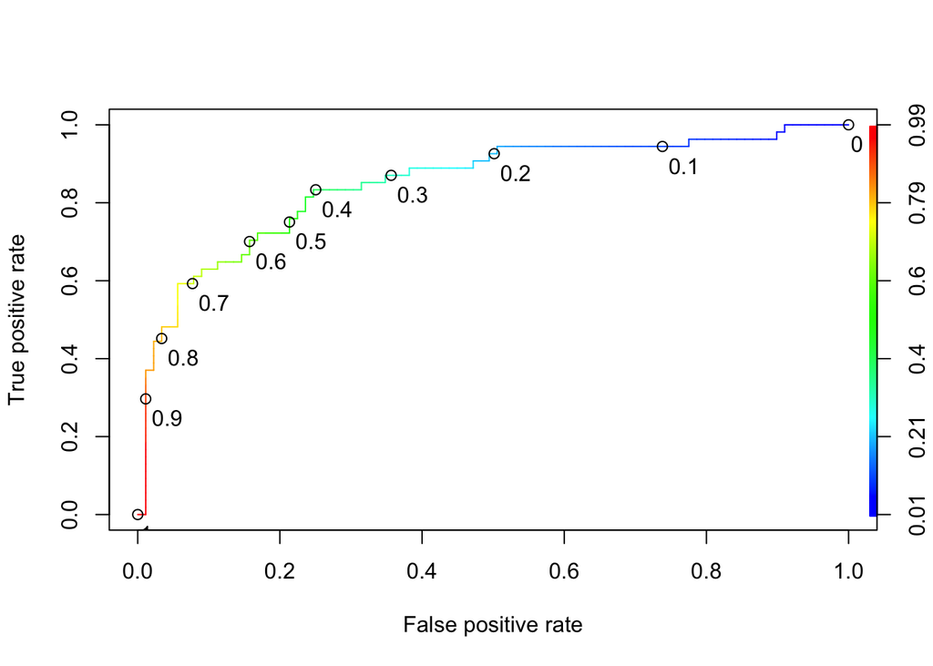

```r
library(ROCR)
predictions <- predict(model,newdata = test,type = "response")
ROCR_predictions <- prediction(predictions,test$Survived)
ROCR_performance <- performance(ROCR_predictions, measure = "tpr", x.measure = "fpr")

plot(ROCR_performance, colorize = TRUE, text.adj = c(-0.2,1.7), print.cutoffs.at = seq(0,1,0.1))
```

```r
auc <- performance(ROCR_predictions, measure = "auc")
auc <- auc@y.values[[1]]
auc
```

```
## [1] 0.8499792
```

# Question 2

### PART A

Flowchart for the Forward Selection

```r
library(DiagrammeR)

grViz("digraph{

# initiate graph
graph [layout = dot, rankdir = TB, label = 'Forward Selection\n\n',labelloc = t]

# global node settings
node [shape = square, style = filled, fillcolor = yellow]



# set up node layout


      2 [label= 'First regressor selected to be entered into \n the model is the one with the highest correlation with the response. \n Check p-value corresponding to the model containing this variable.']
      3 [label= 'The regressor is left in the model']
      4 [label= 'The other regressor examined is the one with \n the largest partial correlation with the response']
      5 [label= 'The regressor is retained']


      2 -> 3 [label = 'p-value < alpha-to-enter'];
      3 -> 4
      2 -> 4 [label = 'p-value > alpha-to-enter'];
      4 -> 5 [label = 'p-value < alpha-to-enter'];
      5 -> 4
      4 -> 4 [label = 'p-value > alpha-to-enter'];
}")
```

[interactive chart not shown]

Flowchart of Backward Elimination

```r
grViz("digraph{

# initiate graph
graph [layout = dot, rankdir = TB, label = 'Backward Elimination\n\n',labelloc = t]

# global node settings
node [shape = rectangle, style = filled, fillcolor = red]



# set up node layout


      2 [label= 'The partial F statistic is calculated for each variable as if \n it were the last one added to the model. The regressor with the highest p-value is examined first.']
      3 [label= 'The regressor is removed, and the model is refit with the remaining regressor variables']



      2 -> 3 [label = 'p-value > alpha-to-out'];
      3 -> 2 [label = 'untill all regressors are examined'];

}")
```

[interactive chart not shown]

Flowchart for the Stepwise Regression Model

```r
grViz("digraph{

# initiate graph
graph [layout = dot, rankdir = TB, label = 'Stepwise Regression Model\n\n',labelloc = t]

# global node settings
node [shape = rectangle, style = filled, fillcolor = green]



# set up node layout


      2 [label= 'Regression model without any explanatory variables']
      3 [label= 'Add one explanatory variable not contained in \n the model to the regression model and record significance using AIC']
      4 [label = 'Are any explanatory variables untested ?']
      5 [label = 'Is the model without additional explanatory variable  \n more significant than models with additional variable?']
      6 [label = 'Stop']
      7 [label = 'Add the most significant (i.e. least AIC) explanatory variable to the regression model']

      2 -> 3 ;
      3 -> 4 [label= 'Yes'] ;
      4 -> 5 [label= 'No'];
      5 -> 6 [label= 'Yes'];
      6 -> 7 [label= 'No']
      7 -> 3

}")
```

[interactive chart not shown]

### PART B

Regression models can not get the best option or validated most of the time but it does not mean that it is unnecessary and unimportant.We all know that regression is the most accessible and basic appropriate tool for the basic analysis. We get benefit to much for the regression in our analysis.

Basically when we are building a model, regression help us to understand the connection between the response and predictors with more appropriate than any other tools or models. That’s why we choose the linear regression models are much more preferable than non-linear models.

In conclusion, especially in data analysis, regression model is one of the crucial and effective models and we can not underestimate the importance of these models.

### PART C

The dean of a graduate school can examine variables for the students such as amount of school project, amount of research, writing skills, integrity,trustworthiness ,positive attitude, language skills, number of certificate,voluntary works,gpa value, number of references and number of seminars.

### PART D

The alpha-to-enter value for adding variables should not exceed the alpha-to-remove value for eliminating variables in forward stepwise regression. A variable can be maintained in and removed from the model if the alpha-to-enter value for adding variables exceeds the alpha-to-remove value for deleting variables.That’s why, should the alpha-to-enter value for adding variables never exceed the alpha-to-remove value for deleting variables.

# Question 3

```r
#Read the dataset
job <- read_excel("job_model_building_data.xlsx")
head(job)
```

```
## # A tibble: 6 × 5
##      x1    x2    x3    x4     y
##   <dbl> <dbl> <dbl> <dbl> <dbl>
## 1    86   110   100    87    88
## 2    62    97    99   100    80
## 3   110   107   103   103    96
## 4   101   117    93    95    76
## 5   100   101    95    88    80
## 6    78    85    95    84    73
```

### PART A

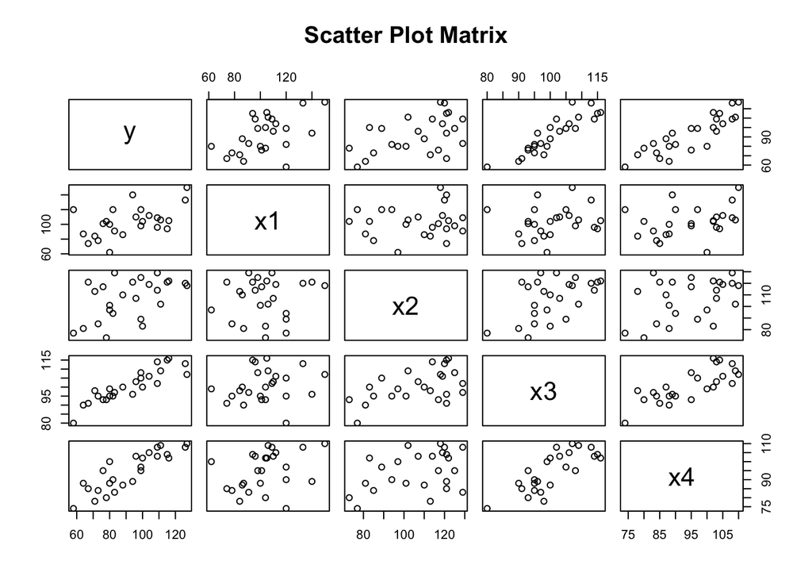

```r
library(Hmisc)
pairs(~y + x1 +x2 +x3 +x4, data = job, main = "Scatter Plot Matrix")
```

```r
rcorr(as.matrix(cor(job)))$r
```

```
##            x1          x2         x3          x4          y
## x1  1.0000000 -0.83057750 -0.6438983 -0.35530034 -0.2369301
## x2 -0.8305775  1.00000000  0.2647492 -0.08496202 -0.1428578
## x3 -0.6438983  0.26474921  1.0000000  0.83704834  0.8837081
## x4 -0.3553003 -0.08496202  0.8370483  1.00000000  0.9211419
## y  -0.2369301 -0.14285784  0.8837081  0.92114191  1.0000000
```

It’s obvious that x3, x4 between y have strong linear relationship. However,also x3 and x4 seem to have serious multicollinearity problem.

### PART B

```r
model2 <- lm(y ~ . , data = job)
summary(model2)
```

```
##
## Call:
## lm(formula = y ~ ., data = job)
##
## Residuals:
##     Min      1Q  Median      3Q     Max
## -5.9779 -3.4506  0.0941  2.4749  5.9959
##
## Coefficients:
##               Estimate Std. Error t value Pr(>|t|)
## (Intercept) -124.38182    9.94106 -12.512 6.48e-11 ***
## x1             0.29573    0.04397   6.725 1.52e-06 ***
## x2             0.04829    0.05662   0.853  0.40383
## x3             1.30601    0.16409   7.959 1.26e-07 ***
## x4             0.51982    0.13194   3.940  0.00081 ***
## ---
## Signif. codes:  0 '***' 0.001 '**' 0.01 '*' 0.05 '.' 0.1 ' ' 1
##
## Residual standard error: 4.099 on 20 degrees of freedom
## Multiple R-squared:  0.9629, Adjusted R-squared:  0.9555
## F-statistic: 129.7 on 4 and 20 DF,  p-value: 5.262e-14
```

The multiple linear equation is:
$$\hat{y}
= -124.38182 + 0.295X_1+0.048X_2+1.306X_3+0.5198X_4$$

### PART C

```r
library(leaps)

best <- function(model2, ...)
{
  subsets <- regsubsets(formula(model2), model.frame(model2), ...)
  subsets <- with(summary(subsets),
                  cbind(p = as.numeric(rownames(which)), which, adjr2))

  return(subsets)
}

round(best(model2, nbest = 6), 4)
```

```
##   p (Intercept) x1 x2 x3 x4  adjr2
## 1 1           1  0  0  1  0 0.7962
## 1 1           1  0  0  0  1 0.7452
## 1 1           1  1  0  0  0 0.2326
## 1 1           1  0  1  0  0 0.2143
## 2 2           1  1  0  1  0 0.9269
## 2 2           1  0  0  1  1 0.8661
## 2 2           1  1  0  0  1 0.7985
## 2 2           1  0  1  1  0 0.7884
## 2 2           1  0  1  0  1 0.7636
## 2 2           1  1  1  0  0 0.4155
## 3 3           1  1  0  1  1 0.9560
## 3 3           1  1  1  1  0 0.9247
## 3 3           1  0  1  1  1 0.8617
## 3 3           1  1  1  0  1 0.8233
## 4 4           1  1  1  1  1 0.9555
```

Since $R^2_{a,p}$ won’t decrease as number of parameter increases, We should take a look at the absolute value of printed adjusted R square. According to the above table value : For the subset x1,x3,x4 $R^2_{a,p}$ is 0.956. For the subset x1,x2,x3,x4 $R^2_{a,p}$ is 0.955. For the subset x1,x3 $R^2_{a,p}$ is 0.927. For the subset x1,x2,x3, $R^2_{a,p}$ is 0.925 .

### PART D

```r
library(MASS)
begin = lm(y ~ 1, job)
addterm(begin, scope = model2, test="F")
```

|  | Df | Sum of Sq | RSS | AIC | F Value | Pr(F) |
| --- | --- | --- | --- | --- | --- | --- |
|  | NA | NA | 9054.000 | 149.3022 | NA | NA |
| x1 | 1 | 2395.855 | 6658.145 | 143.6180 | 8.276277 | 8.517216e-03 |
| x2 | 1 | 2236.471 | 6817.529 | 144.2094 | 7.545084 | 1.148695e-02 |
| x3 | 1 | 7285.977 | 1768.023 | 110.4685 | 94.782415 | 1.264307e-09 |
| x4 | 1 | 6843.311 | 2210.689 | 116.0546 | 71.197796 | 1.698598e-08 |

```r
New2 = update( begin, .~. + x3)
addterm( New2, scope = model2, test="F" )
```

|  | Df | Sum of Sq | RSS | AIC | F Value | Pr(F) |
| --- | --- | --- | --- | --- | --- | --- |
|  | NA | NA | 1768.0228 | 110.46853 | NA | NA |
| x1 | 1 | 1161.3654 | 606.6574 | 85.72721 | 42.1160886 | 1.577770e-06 |
| x2 | 1 | 12.2102 | 1755.8127 | 112.29528 | 0.1529914 | 6.994553e-01 |
| x4 | 1 | 656.7102 | 1111.3126 | 100.86053 | 13.0005053 | 1.570064e-03 |

```r
New2 = update( New2, .~. + x1)
dropterm(New2 , test = "F")
```

|  | Df | Sum of Sq | RSS | AIC | F Value | Pr(F) |
| --- | --- | --- | --- | --- | --- | --- |
|  | NA | NA | 606.6574 | 85.72721 | NA | NA |
| x3 | 1 | 6051.488 | 6658.1453 | 143.61801 | 219.45290 | 6.313011e-13 |
| x1 | 1 | 1161.365 | 1768.0228 | 110.46853 | 42.11609 | 1.577770e-06 |

```r
addterm( New2, scope = model2, test="F" )
```

|  | Df | Sum of Sq | RSS | AIC | F Value | Pr(F) |
| --- | --- | --- | --- | --- | --- | --- |
|  | NA | NA | 606.6574 | 85.72721 | NA | NA |
| x2 | 1 | 9.936759 | 596.7207 | 87.31433 | 0.3496978 | 0.5605965035 |
| x4 | 1 | 258.460440 | 348.1970 | 73.84732 | 15.5879261 | 0.0007353614 |

```r
New2 = update( New2, .~. + x4)
dropterm( New2, test = "F" )
```

|  | Df | Sum of Sq | RSS | AIC | F Value | Pr(F) |
| --- | --- | --- | --- | --- | --- | --- |
|  | NA | NA | 348.1970 | 73.84732 | NA | NA |
| x3 | 1 | 1324.3882 | 1672.5853 | 111.08125 | 79.87476 | 1.333807e-08 |
| x1 | 1 | 763.1156 | 1111.3126 | 100.86053 | 46.02402 | 1.039704e-06 |
| x4 | 1 | 258.4604 | 606.6574 | 85.72721 | 15.58793 | 7.353614e-04 |

```r
addterm( New2, scope = model2, test="F" )
```

|  | Df | Sum of Sq | RSS | AIC | F Value | Pr(F) |
| --- | --- | --- | --- | --- | --- | --- |
|  | NA | NA | 348.1970 | 73.84732 | NA | NA |
| x2 | 1 | 12.21949 | 335.9775 | 74.95421 | 0.727399 | 0.4038262 |

Start with no predictors, as we shown from the above table, choose x3 since it has the lowest p-value (1.264e-09 < 0.05).

After that, when y is regressed on x3, x1, and either of the other two, it is revealed that x4 has the smallest p-value (0.0007354 < 0.05), indicating that it should be included in the model.

### PART E

The model examined using forward stepwise regression yields the same result as the one I chose earlier using adjusted R square criterion (you can see top of the list).

### PART F

```r
Press_value = sum((model2$residuals/(1-hatvalues(model2)))^2)
Press_value
```

```
## [1] 518.9885
```

### PART G

```r
job_validation <- read_excel("job_validation_data.xlsx")
head(job_validation)
```

| x1 | x2 | x3 | x4 | y |
| --- | --- | --- | --- | --- |
| 65 | 109 | 88 | 84 | 58 |
| 85 | 90 | 104 | 98 | 92 |
| 93 | 73 | 91 | 82 | 71 |
| 95 | 57 | 95 | 85 | 77 |
| 102 | 139 | 101 | 92 | 92 |
| 63 | 101 | 93 | 84 | 66 |

```r
correlation_job_validation <- cor(job_validation)
correlation_job_validation
```

```
##            x1         x2        x3        x4         y
## x1 1.00000000 0.01057088 0.1772891 0.3196395 0.5370779
## x2 0.01057088 1.00000000 0.3437441 0.2207638 0.3447744
## x3 0.17728907 0.34374413 1.0000000 0.8714466 0.8880519
## x4 0.31963945 0.22076377 0.8714466 1.0000000 0.8879388
## y  0.53707787 0.34477442 0.8880519 0.8879388 1.0000000
```

### PART H

```r
new_model <- lm(y~.,data=job_validation)
summary(new_model)
```

```
##
## Call:
## lm(formula = y ~ ., data = job_validation)
##
## Residuals:
##     Min      1Q  Median      3Q     Max
## -7.3312 -2.6117 -0.1671  3.0793  6.3339
##
## Coefficients:
##               Estimate Std. Error t value Pr(>|t|)
## (Intercept) -123.69739   11.33348 -10.914 7.12e-10 ***
## x1             0.31204    0.04519   6.905 1.05e-06 ***
## x2             0.07924    0.04574   1.732   0.0986 .
## x3             1.28105    0.23381   5.479 2.31e-05 ***
## x4             0.48220    0.19125   2.521   0.0203 *
## ---
## Signif. codes:  0 '***' 0.001 '**' 0.01 '*' 0.05 '.' 0.1 ' ' 1
##
## Residual standard error: 4.094 on 20 degrees of freedom
## Multiple R-squared:  0.9556, Adjusted R-squared:  0.9467
## F-statistic: 107.5 on 4 and 20 DF,  p-value: 3.174e-13
```

Comparing of the MSRES values.

```r
data.frame(model_building_set_parameter_estimation=summary(model2)$coefficients[,1],
validation_set_parameter_estimation=summary(new_model)$coefficients[,1],
model_building_set_se_estimation=summary(model2)$coefficients[,2],
validation_set_se_estimation=summary(new_model)$coefficients[,2])
```

|  | model_building_set_parameter_estimation | validation_set_parameter_estimation | model_building_set_se_estimation | validation_set_se_estimation |
| --- | --- | --- | --- | --- |
| (Intercept) | -124.38182058 | -123.69738917 | 9.94106316 | 11.33348374 |
| x1 | 0.29572537 | 0.31204492 | 0.04397141 | 0.04519058 |
| x2 | 0.04828772 | 0.07924145 | 0.05661745 | 0.04574254 |
| x3 | 1.30601100 | 1.28105375 | 0.16409129 | 0.23381286 |
| x4 | 0.51981909 | 0.48219877 | 0.13194285 | 0.19124753 |

In model creation and validation sets, the parameter estimates for census appear to be different. In addition, the intercept’s standard error estimate differs across the two models. Let’s look at the MSRES values side by side.

```r
deviance(model2)/model2$df.residual
```

```
## [1] 16.79888
```

```r
deviance(new_model)/new_model$df.residual
```

```
## [1] 16.75813
```

MSRES values seem to be close. Now, let’s compare R2 values of the two models.

```r
summary(model2)$r.squared
```

```
## [1] 0.9628918
```

```r
summary(new_model)$r.squared
```

```
## [1] 0.9555567
```

In conclusion, the validation set fits the model.

### PART I

```r
predicted <- predict(model2, job_validation)
mean((job_validation$y - predicted)^2)
```

```
## [1] 13.95808
```

```r
deviance(model2)/model2$df.residual
```

```
## [1] 16.79888
```

We can see that, MSE from the model-building data set and the mean prediction error are close. Thus, there is no evidence of substantial bias problem in MSE here.

### PART J

```r
combine <- merge(job,job_validation,by=c("x1", "x2", "x3", "x4", "y"), all=TRUE)
head(combine)
```

|  | x1 | x2 | x3 | x4 | y |
| --- | --- | --- | --- | --- | --- |
| 1 | 62 | 97 | 99 | 100 | 80 |
| 2 | 63 | 101 | 93 | 84 | 66 |
| 3 | 65 | 109 | 88 | 84 | 58 |
| 4 | 67 | 98 | 98 | 84 | 66 |
| 5 | 74 | 121 | 91 | 85 | 67 |
| 6 | 78 | 85 | 95 | 84 | 73 |

```r
fit_combine_data <- lm(y~., data=combine)
summary(fit_combine_data)
```

```
##
## Call:
## lm(formula = y ~ ., data = combine)
##
## Residuals:
##     Min      1Q  Median      3Q     Max
## -7.7562 -2.6566  0.2065  2.9487  6.6919
##
## Coefficients:
##               Estimate Std. Error t value Pr(>|t|)
## (Intercept) -124.22595    6.95205 -17.869  < 2e-16 ***
## x1             0.30356    0.02976  10.202 2.77e-13 ***
## x2             0.06710    0.03347   2.004   0.0511 .
## x3             1.28808    0.12564  10.252 2.37e-13 ***
## x4             0.50575    0.10189   4.964 1.04e-05 ***
## ---
## Signif. codes:  0 '***' 0.001 '**' 0.01 '*' 0.05 '.' 0.1 ' ' 1
##
## Residual standard error: 3.88 on 45 degrees of freedom
## Multiple R-squared:  0.9603, Adjusted R-squared:  0.9567
## F-statistic: 271.8 on 4 and 45 DF,  p-value: < 2.2e-16
```

Combined last model equation:

$$\hat{y} = -124.22595 +
0.3035X_1+0.06710X_2+1.288X_3+0.5057X_4$$
Standart Errors of parameter:

B0 : 6.95205 B1 : 0.02976 B2 : 0.03347 B3 : 0.12564 B4 : 0.10189

The estimated standard deviations of the estimated regression coefficients are now significantly reduced from those obtained for the model building data set.